# Demographic consequences of mutualism disruption: Browsing and big‐headed ant invasion drive acacia population declines - Hays - 2022 - Ecology - Wiley Online Library

[Ecology](https://esajournals.onlinelibrary.wiley.com/journal/19399170)

[Volume 103, Issue 5](https://esajournals.onlinelibrary.wiley.com/toc/19399170/2022/103/5) e3655

ARTICLE

Full Access

# Demographic consequences of mutualism disruption: Browsing and big-headed ant invasion drive acacia population declines

[Brandon R. Hays](https://esajournals.onlinelibrary.wiley.com/action/doSearch?ContribAuthorRaw=Hays%2C+Brandon+R),

[Corinna Riginos](https://esajournals.onlinelibrary.wiley.com/action/doSearch?ContribAuthorRaw=Riginos%2C+Corinna),

[Todd M. Palmer](https://esajournals.onlinelibrary.wiley.com/action/doSearch?ContribAuthorRaw=Palmer%2C+Todd+M),

[Daniel F. Doak](https://esajournals.onlinelibrary.wiley.com/action/doSearch?ContribAuthorRaw=Doak%2C+Daniel+F),

[Benard C. Gituku](https://esajournals.onlinelibrary.wiley.com/action/doSearch?ContribAuthorRaw=Gituku%2C+Benard+C),

[Nelly J. Maiyo](https://esajournals.onlinelibrary.wiley.com/action/doSearch?ContribAuthorRaw=Maiyo%2C+Nelly+J),

[Samuel Mutisya](https://esajournals.onlinelibrary.wiley.com/action/doSearch?ContribAuthorRaw=Mutisya%2C+Samuel),

[Simon Musila](https://esajournals.onlinelibrary.wiley.com/action/doSearch?ContribAuthorRaw=Musila%2C+Simon),

[Jacob R. Goheen](https://esajournals.onlinelibrary.wiley.com/action/doSearch?ContribAuthorRaw=Goheen%2C+Jacob+R),

First published: 07 February 2022

https://doi.org/10.1002/ecy.3655

**Handling Editor::** Nicholas J. Gotelli

## Abstract

Across the globe, biological invasions have disrupted mutualisms, producing reverberating consequences for ecosystems. Although invasive species frequently trigger mutualism disruptions, few studies have quantified the demographic mechanisms by which mutualism breakdown may generate population effects. In a Kenyan savanna, the invasive big-headed ant (*Pheidole megacephala*) has disrupted a foundational mutualism between the monodominant whistling-thorn tree (*Acacia drepanolobium*) and native ants (*Crematogaster* spp.) that deter browsing by large mammalian herbivores. We conducted experiments to quantify the demographic consequences of this mutualism disruption in the presence and absence of large mammalian herbivores. Invasion by *P. megacephala* exacerbated population declines of *A. drepanolobium*, primarily through decreased survival and reproduction of adult trees. However, these fitness reductions were small compared to those resulting from the presence of large mammalian herbivores, which negatively impacted growth and survival. Contrary to expectation, the expulsion of metabolically costly *Crematogaster* mutualists by *P. megacephala* did not result in higher population growth rates for trees protected from large mammalian herbivores. Our results suggest that invasive *P. megacephala* may impose a direct metabolic cost to trees exceeding that of native mutualists while providing no protection from browsing by large mammalian herbivores. Across landscapes, we expect that invasion by *P. megacephala* will reduce *A. drepanolobium* populations, but that the magnitude and demographic pathways of this effect will hinge on the presence and abundance of browsers.

## INTRODUCTION

Mutualisms are ecologically widespread and often central to ecosystem functions such as seed dispersal, pollination, and nutrient cycling (Olesen & Jordano, 2002; Sekercioglu, 2006; van der Heijden et al., 2015). Increasingly, however, species invasions are disrupting mutualisms (Traveset & Richardson, 2014), negatively impacting ecosystems and biodiversity across the globe (Mack et al., 2000). Invasive species commonly impact native plants by disrupting pollination or seed dispersal mutualisms, either by consuming reproductive structures or by displacing native mutualists via competition or predation (e.g., Rogers et al., 2017; Traveset & Richardson, 2006; Vázquez & Simberloff, 2004). In other instances, invasive species alter soil properties through competition with mycorrhizae or by allelopathically altering soil chemistry (Shah et al., 2009; Traveset & Richardson, 2014). In these and other contexts, mutualisms strongly influence demographic processes such as survival, growth, and reproduction (Janzen, 1966; Palmer & Brody, 2013; Rogers et al., 2017); mutualisms thus play a strong role in regulating population dynamics for at least one partner species in many mutualistic systems (Holland et al., 2002).

Although there have been numerous investigations showing population declines as a result of mutualism disruption by invasive species (reviewed in Traveset & Richardson, 2006), few efforts have documented the demographic pathways by which mutualism disruptions alter populations (though see Palmer et al., 2010). Similarly, while the relative costs and benefits of mutualisms depend upon abiotic conditions and other biotic interactions (Boucher et al., 1982; Hoeksema & Bruna, 2015), ecologists have rarely quantified whether and how the effects of mutualism disruption by invasive species hinge on such environmental context (though see Ford et al., 2015). For example, the net effect of mutualism disruption on mycorrhizae-associated trees should differ based on nutrient availability (Shah et al., 2009). To predict the consequences of mutualism disruption for populations across environmental gradients, research on the demographic pathways and context dependency of these disruptions is a priority (Hoeksema & Bruna, 2015). More broadly, there are still few studies of mutualisms, intact or disrupted, that link the benefits and costs of the interaction to their demographic consequences and hence to either fitness or population dynamics (but see Palmer & Brody, 2013, Rogers et al., 2017).

Ant–plant protection mutualisms—in which ants protect plants from herbivores in exchange for some combination of food and shelter—have helped build our understanding of the ecology and evolution of mutualisms (e.g., Bronstein, 1998; Mayer et al., 2014; Palmer et al., 2003). These mutualisms are increasingly subject to disruption by invasive species (e.g., Lach, 2003; Ludka et al., 2015). When protection mutualisms are disrupted, individual host plants typically incur elevated levels of herbivory, parasitism, or both, with uncertain consequences for population dynamics (Liere & Larsen, 2010; Riginos et al., 2015). In addition, partitioning the unique effect of invasive species on ant-plant protection mutualisms often is challenging, as other human disturbances frequently go hand in hand with species invasions (Kiers et al., 2010).

Across vast swathes of savanna in East Africa, the foundational tree *Acacia* (*Vachellia*) *drepanolobium* forms nearly monodominant stands on poorly drained “black cotton” soils, typically composing >95% of woody plant cover (Young et al., 1997). *Acacia drepanolobium* is a myrmecophyte, hosting a community of four competing ant symbionts that deter catastrophic (partial to whole tree) herbivory by elephants (*Loxodonta africana*) and thereby stabilize tree cover across entire landscapes (hundreds to thousands of square kilometers; Goheen & Palmer, 2010, Palmer & Brody, 2013). In exchange for shelter (swollen-thorn domatia) and food (extrafloral nectar), ants protect trees by aggressively swarming in response to browsing (Palmer et al., 2010). However, provisioning of nectar and domatia comes at a metabolic cost to host plants: trees with even the most mutualistic ant symbionts grow more slowly and produce fewer fruits than those from which ant symbionts have been removed (Palmer & Brody, 2013; Stanton & Palmer, 2011). Thus, as with all obligate mutualisms, there exists a trade-off between benefits received and costs paid by each participant, the balance of which is determined by environmental context (Boucher et al., 1982).

Recently, this ant–acacia mutualism has been disrupted by the advent of an invasive ant, *Pheidole megacephala*. Commonly known as the big-headed ant, this species is widespread throughout the tropics and subtropics (Wetterer, 2007). By forming supercolonies, these invasive ants are able to dominate expansive areas (Pietrek et al., 2021), suppressing native invertebrates and diminishing biodiversity (Wetterer, 2007). In the Laikipia region of Kenya, *P. megacephala* initially established in areas of human activity and spread into the surrounding savanna, extirpating native *Crematogaster* ants, including the two species that most effectively defend host trees (Riginos et al., 2015). *Crematogaster sjostedti*, an antagonistic, native symbiont considered in previous research on this ant–acacia mutualism, is only present in our study area at very low numbers. The ground-nesting *P. megacephala* neither inhabit nor defend trees, leaving *A. drepanolobium* vulnerable to browsing; as a result, trees whose *Crematogaster* symbionts have been expunged suffer increased catastrophic herbivory at the trunks of elephants (Riginos et al., 2015). Although one strongly colonizing symbiont (*Tetraponera penzigi*) persists in invaded areas (Palmer et al., 2020), it defends trees less aggressively than the displaced *Crematogaster* ants (Palmer et al., 2010).

We undertook a multi-year, large-scale demographic experiment to quantify the effect of *P. megacephala* invasion on populations of *A. drepanolobium* in the presence and absence of LMH. Such combinations of experimental manipulations and demographic methods are useful for disentangling the effects of multiple environmental factors (Louthan et al., 2018; Maclean et al., 2011). We simulated four species interaction scenarios based on the 2 × 2 combination of *P. megacephala* invasion and exposure to LMH. For tree populations exposed to LMH in uninvaded areas, we expected population growth rates (*λ*) not to differ statistically from 1.0 (i.e., population stability, inferred via bootstrapped confidence intervals of stochastic *λ* [e.g., Arias-Medellín et al., 2016; Layton-Matthews et al., 2018]) over the course of 4 years (Figure 1, Scenario 1). This scenario represents a pre-invasion (reference) population, which serves as a control for comparisons to our other treatments. Following exclusion of LMH in uninvaded areas, we expected *λ* to exceed 1.0, since trees would not be subjected to any herbivory by elephants and other LMH (although they would still pay the metabolic cost of mutualism; Figure 1, Scenario 2). In invaded areas in which tree populations were exposed to LMH, we expected populations to decrease (*λ* < 1) due to the combination of browsing and loss of protection by native *Crematogaster* ants (Figure 1, Scenario 3). Finally, in invaded areas where LMH were excluded, we expected tree populations to exhibit the highest *λ* because they were freed from both the metabolic costs of the mutualism and herbivory by elephants and other LMH (Figure 1, Scenario 4).

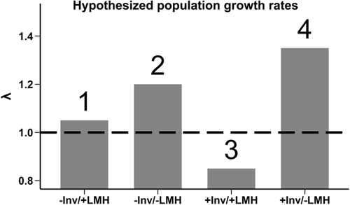

**FIGURE 1**

Hypothesized *A. drepanolobium* population growth rates (*λ*) under four scenarios resulting from the combination of exposure to large mammalian herbivores and *P. megacephala* invasion. We expected that populations protected from large mammalian herbivores (-LMH) would increase (*λ* > 1), while populations exposed to them (+LMH) would remain stable or decline (*λ* ≤ 1). Because *P*. *megacephala* kill native *Crematogaster* ants that defend host trees, and because trees pay a metabolic cost to house *Crematogaster* ants, we expected *P. megacephala* invasion (+Inv) to increase *λ* for trees protected from LMH, but to decrease *λ* for trees exposed to LMH

## METHODS

### Study system

The Laikipia plateau of Kenya is a woody savanna ecosystem containing no formally protected areas; it is a mosaic of properties that vary in their tolerance for wildlife (Georgiadis et al., 2007). Wildlife conservancies house an abundant and diverse suite of small to large mammalian herbivores, including browsing megaherbivores (e.g., giraffes [*Giraffa camelopardalis reticulata*], black rhinoceros [*Diceros bicornis*], elephants; hereafter collectively referred to as LMH). By contrast, other properties fence out or otherwise discourage LMH and are largely managed for crops or livestock. Invasive *P. megacephala* occur on both conservancies and agricultural properties and have the potential to spread across each (C. Riginos and J. R. Goheen, personal observation). Thus, quantifying the demographic mechanisms by which ongoing *P. megacephala* invasion affects acacia populations, including effects that may be contingent on LMH presence, is key to understanding how the landscape may be changing.

We conducted our study on Ol Pejeta Conservancy (hereafter OPC), a 360-km<sup>2</sup> property in Laikipia, Kenya, managed for wildlife conservation, tourism, and cattle ranching. This conservancy is located ~30 km to the south of Mpala Research Centre, where much previous work on ant-acacia mutualisms has been conducted. Community composition of both ants and LMH differ between Mpala Research Centre and Ol Pejeta Conservancy. Importantly, *C. sjostedti*, an antagonistic species that does not rely on swollen-thorn domatia or extra-floral nectar, occupies ~2% of *A. drepanolobium* at OPC, compared to ~20% at Mpala Research Centre (Palmer et al., 2008). Ol Pejeta Conservancy has higher LMH biomass than other properties in Laikipia and houses a relatively abundant population of black rhinoceros (absent from Mpala Research Centre), which rely on *A. drepanolobium* as a primary food (Kartzinel et al., 2015). The average elevation of OPC is 1810 m and the average annual rainfall (2016–2020) was 809 ± 18 mm (mean ± SEM). The time period of our study (2017–2020) spanned years of both high and low rainfall (Appendix S1: Figure S1). The conservancy is situated almost entirely on heavy clay, black-cotton soils where hillsides are dominated almost exclusively by *A. drepanolobium* (Wahungu et al., 2009). The invasive *P. megacephala* likely arrived at OPC before 2005 (Riginos et al., 2015). In a concurrent study, we mapped the spatial distribution of *P. megacephala* invasion to guide our experimental design (Pietrek et al., 2021).

### Experimental design

In January of 2017, we established 12 2500-m<sup>2</sup> study plots (50 × 50 m) across OPC in a 2 × 2 factorial design. For each of three sets of replicated plots (sites), a pair of plots was established on each side of an invasion front (the furthest extent of *P. megacephala* spread). Two plots were located between 0.5 and 2.5 km behind an invasion front (hereafter “invaded plots” or “+ Invasion”) and two plots were located a similar distance beyond the same invasion front (hereafter “uninvaded plots” or “−Invasion”). We avoided establishing plots in areas containing or adjacent to termite mounds, which affect reproduction of *A. drepanolobium* (Brody et al., 2010). Since *P. megacephala* spread at a rate of ~50 m/year (Pietrek et al., 2021), this ensured both that uninvaded plots would not be invaded during our study, and that invaded plots represented longer-term (≥5 years) effects of invasion. Prior to plot establishment, we verified that no trees in invaded areas hosted the strongly defensive *Crematogaster* species any longer, though *T. penzigi* (a weak defender) persisted at low densities. To exclude LMH, we constructed electrified fences around one invaded and one uninvaded plot at each site. The fences consisted of two metal wires ~0.4 and 0.8 m above the ground with short lengths of wire (~0.5 m) projecting outwards from the top wire at regular intervals. These fences effectively excluded LMH and also medium-sized ungulates, while enabling smaller (≤10 kg) herbivores to access the plots. Since the fences excluded both large browsers and large grazers, we periodically grazed cattle within fenced plots to maintain grass stubble height at a level comparable to surrounding areas, thereby controlling for competitive suppression of tree growth by grasses (Riginos, 2009). Thus, our experimental design consisted of three treatment conditions representing future changes to the landscape (invaded areas with LMH excluded, invaded areas with LMH present, and uninvaded areas with LMH removed) and one reference condition (uninvaded areas with LMH present). A map of the study design is provided in the supplemental materials (Appendix S1: Figure S2).

### Data collection

Each January from 2017 to 2020, we collected demographic data on a structured sample of trees within study plots. We divided trees into five broad categories based on height (<0.5 m, 0.5–1.5 m, 1.5–2.5 m, 2.5–3.5 m, >3.5 m) and recorded data for 10 trees randomly selected within each category, within each plot. Trees were individually tagged to allow for resurveying in subsequent years. Our selection encompassed nearly all of the trees >2.5 m but only a sample of trees <0.5 m. *A. drepanolobium* readily coppices after elephants have snapped their main stems. Because we believed coppices might perform differently from non-coppices of similar height (i.e., “saplings”), we recorded data for 10 saplings and 10 coppices in each plot. We defined coppices as trees <0.5 m tall that had clearly been taller (based on their diameter) prior to being browsed. We made every attempt to distinguish coppices from saplings; however, it could be difficult to non-destructively distinguish these groups. We collected data on a maximum of 60 trees within each plot, although not all plots contained 10 trees >3.5 m (range = 1–10 trees >3.5 m per plot). Each year, we measured height (two observers' assessments of maximum canopy extent measured by an extendable measuring pole), stem diameter at 30 cm above ground level (or as close as possible for trees <0.5), ant occupant, conversion to coppice, and mortality. We marked locations of diameter measurements with paint to ensure accuracy of repeat measurements. We verified that mortality events represented true tree deaths, and not conversion to coppices, by revisiting dead trees in subsequent years to check for any growth. Over the course of our study, there were a few occasions when elephants’ broke fences and entered LMH exclusion plots; if study trees were damaged, we stopped recording data for these trees and instead followed a replacement tree of similar size in subsequent years (10 trees in −Invasion/−LMH and seven trees in +Invasion/−LMH treatments).

At OPC, *A. drepanolobium* reproduce between July and September. From May through September, we visited each tree to record whether they were reproductive, as evidenced by the presence of any flower buds, flowers, or fruits. Seeds of *A. drepanolobium* dangle from arils within fruits and are wind dispersed when mature (Goheen et al., 2007). For each tree found to be producing fruit, we returned on a weekly basis until fruits dehisced and then collected all fruits by hand, wearing gloves to avoid scent contamination that might deter post-dispersal seed predators and bias our estimates of germination (Goheen et al., 2010). Seeds were then separated from fruits and subsequently weighed and counted; any seeds with damage from bruchid beetles were discarded both from germination trials and seed production data (<5% of seeds per treatment; Goheen et al., 2010). We detected no difference among our four treatments in bruchid infestation (ANOVA: *F* = 0.299, *df* = 3, *p* = 0.826). To measure seed survival, we scattered all seeds in 1-m<sup>2</sup> plots randomly placed beneath parent trees, with a maximum of 100 seeds per plot. To avoid contamination of germination plots by nearby, non-study trees, we removed fruits from these trees and scattered them outside of the study plots. Any germinants discovered during weekly checks were marked with an individually numbered nail and subsequently monitored every other week for up to 6 months, at which point individuals were assumed to have recruited to the sapling stage (Goheen et al., 2010).

### Demographic analyses

We constructed size-based demographic models using continuous size-based vital rate functions, which can be viewed either as projection matrices or integral projection models (Caswell, 2001; Doak et al., 2021; Morris & Doak, 2002). Using tree height as our size-classifying variable (hereafter “height classes”), we created mixed linear and general linear models for growth, variance in growth, survival, probability of reproduction, and number of seeds produced given reproduction. For each rate, we used AIC<sub>c</sub> to pick the best-supported model or models (AIC<sub>c</sub> < 2.0). We did not create a regression for seed survival both because of limited sample size and because we did not believe that it would vary based on parent tree height (Appendix S1: Table S1). We included year as a random intercept in all vital rate regressions; although we attempted separate random effects of individual tree and plot to control for individual or geographic variation in browsing pressure, these produced overfitting and therefore were not included in subsequent model construction. The predictions of the vital rate regressions were used to populate projection matrices with 64 size classes (seeds plus trees 0.1–6.3 m tall in 0.1 m increments). From these matrices we calculated deterministic and stochastic *λ* values as well as reproductive values (average number of expected offspring produced); we also predicted populations and their size structures 10 years in the future. Greater detail on vital rate statistics and modeling methods is provided in Appendix S2. To account for model and parameter uncertainty, we used a parametric bootstrap to test for significant differences in treatment-specific stochastic *λ* values.

Next, we conducted elasticity analyses to measure the potential contribution of different vital rates to differences in *λ*. Elasticities were calculated analytically by taking the derivatives of matrix elements with respect to component vital rates for a given height class (Caswell, 2001). Finally, we conducted a Life Table Response Experiment (LTRE), to determine the relative contribution of demographic components to differences in *λ* attributable to invasion in the presence and absence of LMH, to LMH in invaded and uninvaded areas, and to the synergistic effect of invasion and LMH. We did this first for each vital rate, pooled across all height classes, and then for individual vital-rate–height-class combinations. We present raw LTRE contributions only for height-class-pooled results (in which non-additive effects between matrix elements are smaller); for height-class specific LTRE results we present relative contributions.

## RESULTS

Our best-supported regression models included a negative effect of LMH on all vital rates except variance in growth, where there was a positive effect; an effect of *P. megacephala* invasion was retained in models for all vital rates except growth (Figure 2, Appendix S1: Table S2). Because *P. megacephala* invasion did not have an effect on growth, no effect of invasion was manifested through this vital rate in the matrix models. Interactions between exposure to LMH and tree height featured in all vital rate regressions except survival, such that slopes of regressions differed with the presence of LMH (Figure 2a–d). Across all vital rates, trees protected from LMH performed better than trees exposed to LMH. For height classes <0.5 m, trees exposed to LMH had lower variance in growth (near zero). Trees in uninvaded plots generally performed better than trees in invaded plots, most dramatically with respect to seed production (Figure 2d). There was also an interaction between *P. megacephala* invasion and exposure to LMH for probability of reproduction, seed production, and survival (Figure 2c–e). This led to changes in relative probabilities of reproduction between treatments depending on tree height.

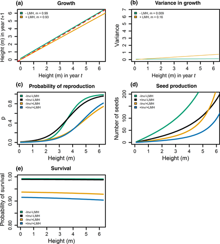

**FIGURE 2**

Vital rate regressions (averaged across years) as a function of *A. drepanolobium* height. For growth (a), the slope of the regression is affected only by presence of LMH and not by *P. megacephala* invasion. The dashed red line in panel (a) represents a slope of 1, in other words where a tree of a given height would be expected to maintain the same height through the following year. For variance in growth (b), the effect of invasion is so small as to be visually indiscernible, so only lines for ± LMH are shown. Both LMH and *P. megacephala* reduced seed production and survival of adult trees. For survival (e), the effect of invasion was stronger in the presence of LMH, whereas for seed production (d) the effect of invasion was stronger in the absence of LMH. For probability of reproduction, there is an interaction between LMH presence, *P. megacephala* invasion, and height. Small trees protected from LMH have higher probabilities of reproduction in invaded areas than in uninvaded areas, but large trees have higher probabilities of reproduction in uninvaded areas. For trees exposed to LMH, the trend is opposite

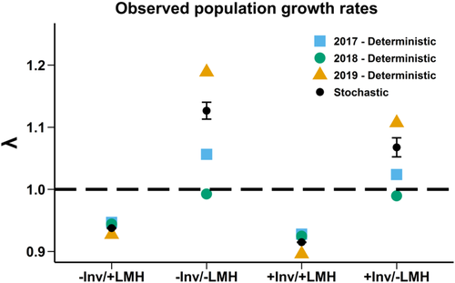

**FIGURE 3**

Observed deterministic population growth rates (*λ*) for each transition year (2017–2019) in each experimental treatment are presented as colored shapes. Stochastic population growth rates calculated from all of the deterministic rates are presented as black circles. Error bars around stochastic *λ* values represent 95% bootstrapped confidence intervals. Stochastic *λ* values are significantly different among all treatments. Both large mammalian herbivores and *P. megacephala* invasion reduce *λ*; although LMH depress *λ* more strongly than invasion, trees exposed to both large mammalian herbivores and *P. megacephala* exhibit the greatest decrease in *λ*

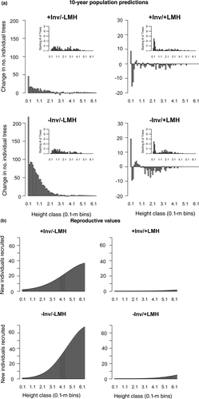

**FIGURE 4**

Our LTRE analysis of vital rates pooled across height classes showed that LMH suppressed *λ* primarily by reducing growth and survival (Table 1). Invasion by *P. megacephala* suppressed *λ* largely by reducing reproduction where LMH were excluded, but this effect was overwhelmed by reduced survival in the presence of LMH (Table 1, Appendix S1: Figure S3). Despite interannual variation, growth and survival were consistently the most important drivers of *λ* across all three transition years, except with respect to the effect of invasion in the absence of LMH, where reproduction was the most important (Appendix S1: Figure S3).

TABLE 1. Summed LTRE contributions of each vital rate to differences in *λ* attributable to *P. megacephala* invasion, large mammalian herbivores (LMH), and their combination, averaged across all three transition years with 95% confidence intervals

|  | Total difference in lambda | Growth (%) | Variance in growth (%) | Survival (%) | Probability of reproduction (%) | Seed production (%) | Seed survival (%) |
| --- | --- | --- | --- | --- | --- | --- | --- |
| Invasion (fenced) | −0.04 ± 0.002 | 0 | 0.8 ± 0.5 | −8.2 ± 0.7 | 13.2 ± 1.1 | −44.8 ± 1.7 | −61.1 ± 2.2 |
| Invasion (unfenced) | −0.02 ± 0.002 | 0 | 0.2 ± 0.2 | −92.3 ± 5.0 | −1.4 ± 0.2 | −4.0 ± 0.4 | −2.5 ± 0.6 |
| LMH (uninvaded) | −0.14 ± 0.002 | −43.4 ± 0.8 | 4.3 ± 0.3 | −33.7 ± 0.5 | −6.8 ± 0.2 | −13.6 ± 0.5 | −6.8 ± 0.5 |
| LMH (invaded) | −0.12 ± 0.002 | −30.2 ± 0.7 | 0.3 ± 0.2 | −53.2 ± 0.8 | −5.9 ± 0.2 | −10.0 ± 0.4 | −1.1 ± 1.0 |
| Synergistic effect | −0.16 ± 0.002 | −34.0 ± 0.6 | 3.5 ± 0.3 | −36.7 ± 0.6 | −5.9 ± 0.2 | −15.4 ± 0.4 | −11.4 ± 0.8 |

- *Note*: The first column is the absolute difference in averaged deterministic *λ*s; the remaining columns are percent contributions of each vital rate to the absolute difference in *λ*. Negative values contribute to the negative total differences in *λ*, but may sum to >100% because of opposing, positive contributions from other vital rates. The first two rows represent effects of invasion, row one in isolation from the effect of LMH (+Inv/−LMH minus −Inv/−LMH) and row two in the presence of LMH (+Inv/+LMH minus −Inv/+LMH). The third and fourth rows represent effects of LMH, row three in isolation from the effect of invasion (−Inv/+LMH minus −Inv/−LMH) and row four with invasion (+Inv/+LMH minus +Inv/−LMH). The final row represents the synergistic effect of invasion and LMH (+Inv/+LMH minus −Inv/−LMH). Because the vital rate regression for growth did not include a slope parameter for invasion, it makes no contribution in rows one and two.

When separated by height classes, LTRE contributions revealed the differential importance of trees of varying heights in driving *λ*. Such contributions are influenced both by vital rate regressions and demographic elasticities (Figure 2, Appendix S1: Figure S4). For trees exposed to LMH, *λ* was most elastic to changes in growth and survival of the smallest trees (<0.5 m) and was relatively insensitive to reproduction (i.e., both probability of reproduction and seed production). Trees protected from LMH exhibited lower elasticity overall, but elasticity was variable across height classes for reproduction (Appendix S1: Figure S4). Height-class specific results from our LTRE mirrored patterns in elasticity values. In the presence of LMH, the negative effect of invasion manifested most strongly through reductions in survival of the smallest trees (≤0.5 m, Figure 5b, Table 1 row 2), while in the absence of LMH it manifested through reduced reproduction in medium-sized trees (0.6–3.5 m, Figure 5a, Table 1 row 1). This was due to the combination of low survival rates in +Inv/+LMH treatments (Figure 2e) and variance in growth near zero for the smallest trees in populations exposed to LMH (Figure 2b). Since predicted mean tree growth rates (averaged across all 3 years) were less than one (i.e., a tree was more likely to shrink than grow) for all but the smallest size classes (Figure 2a), a variance near zero precludes the possibility of growth, resulting in low *λ* values. To further illustrate the impact of survival of small trees on *λ*, we set survival of the 10 smallest height classes (0.1–1.1 m) in populations exposed to LMH to be equal to those in populations protected from LMH, causing population growth to stabilize (*λ* ~ 1; Appendix S1: Table S3). Manipulating other vital rates in the same manner did not produce such large increases in *λ*. The negative effect of LMH both in the presence and absence of *P. megacephala* invasion manifested largely through reductions in growth of medium-sized trees and survival of all trees (Figure 5c,d, Table 1 rows 3 and 4). The synergistic effect of both invasion and LMH largely resembled the effect of LMH (Figure 5e, Table 1 row 5).

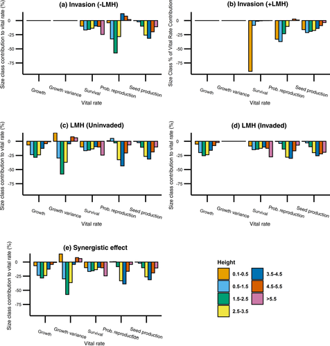

**FIGURE 5**

Percent contribution of each height class to the total calculated differences in *λ* between treatments, per vital rate. Positive numbers represent height classes that contribute to a positive difference in *λ* and negative numbers represent height classes that contribute negatively. All bars sum to 100%. Contributions were calculated in 0.1-m height classes and then aggregated into larger classes for ease of display. (a) The difference due to invasion in the absence of LMH (LTRE of +Inv/−LMH minus −Inv/−LMH). (b) The difference due to invasion in the presence of LMH (+Inv/+LMH minus −Inv/+LMH). (c) The difference due to LMH in uninvaded areas (−Inv/+LMH) minus −Inv/−LMH. (d) The difference due to LMH in invaded areas (+Inv/+LMH minus +Inv/−LMH). (e) The synergistic effect of invasion and LMH (+Inv/+LMH minus −Inv/−LMH). In panels (a) and (b) there is no contribution from growth because there was no effect of *P. megacephala* invasion in that vital rate regression. There is no contribution from growth variance displayed in panels (a), (b), or (d) because that vital rate contributed <1% to those total LTRE differences

## DISCUSSION

We show that mutualism disruption by an invasive ant species alters populations of a monodominant tree by different demographic processes, depending upon environmental context (in the form of browsing). In the presence of LMH, *P. megecephala* invasion decreased tree survival; where LMH were excluded, *P. megacephala* invasion lowered seed production and seed survival. Other studies have shown that invasive species negatively impact native populations by altering a few vital rates through the disruption of native mutualisms (Rogers et al., 2017; Vázquez & Simberloff, 2004). Our study extends these by combining all population vital rates to predict population growth and fitness, and by demonstrating the importance of environmental context dependency through experimental manipulation. The invasive *P. megacephala* reduced population growth rates of *A. drepanolobium* both directly (although this effect was smaller than the effect of LMH alone) and indirectly by disrupting the protective mutualism between *A. drepanolobium* and their native *Crematogaster* ant symbionts.

In contrast to our expectations (Figure 1), the reduction in *A. drepanolobium* population growth triggered by *P. megacephala* occurred regardless of the presence of LMH. Unlike native *Crematogaster* ants, *P. megacephala* neither defend trees nor do they stimulate extrafloral nectar production (Riginos et al., 2015); thus, we predicted that population growth would increase when LMH were excluded (since trees were protected from browsing) following invasion by *P. megacephala*. Instead, tree populations in invaded areas performed worse, even in the absence of LMH. This suggests that, in addition to their (indirect) negative effect of mutualism disruption, *P. megacephala* may also impose a direct (metabolic) cost to individual trees. This is supported by recent evidence from greenhouse experiments showing that *P. megacephala* are parasitizing *A. drepanolobium* saplings by damaging root systems (Milligan et al., in press). This negative effect of invasion may also be partially due to the loss of protection against invertebrate herbivores (which our fences did not exclude), though this may be offset by incidental protection offered by the carnivorous *P. megacephala*. By combining experimental manipulation and demographic analyses, we show that *P. megacephala* exert indirect effects by disrupting a foundational mutualism, as well as potential direct effects through parasitism of the host tree.

Although *P. megacephala* consistently suppressed population growth, their effect on trees manifested through different demographic processes depending on the presence of LMH. Our fences excluded both large grazers and browsers (and thus we could not isolate the effects of either group), but we attribute differences in tree population dynamics between fenced and unfenced plots to browsing, mostly by elephants. Tree populations in invaded areas were characterized by lower survival than their uninvaded counterparts, regardless of browsing pressure; however, the difference in survival and its effect on *λ* were greater when trees were exposed to LMH (Figure 2e). Similarly, while trees protected from LMH exhibited increased reproductive values regardless of invasion, trees in uninvaded areas produced twice as many seeds, which survived at three times the rate as those from invaded areas (Figure 2d, Appendix S1: Table S1). Because we did not control for post-dispersal seed predation, we cannot identify the mechanism underlying this difference in seed fates. However, reduced seed production in invaded areas was not due to an increase in bruchid beetle infestation, a common pre-dispersal seed predator in this system (Goheen et al., 2007). Instead, we suggest this may be attributable to damage to root systems inflicted by *P. megacephala* themselves (Milligan et al., in press), reducing the trees' ability to allocate resources to reproduction. Thus, disruption of the ant–acacia protection mutualism leads to increased tree mortality from LMH browsing and decreased reproduction. In sum, invasion by *P. megacephala* exacerbates the negative effects of LMH browsing and dampens the potentially positive effects of LMH exclusion.

By contrast, the demographic effects of LMH were sufficiently strong to switch *A. drepanolobium* population growth from positive (*λ* > 1) to negative (*λ* < 1), in accordance with previous studies of this tree species (Maclean et al., 2011). Suppression of *λ* by LMH was largely driven by reduced survival and growth, particularly of the smallest (<0.5 m) trees: when survival rates for these were set equal to trees protected from LMH, populations were close to stable. The reduction in survival of small trees was strongest in invaded areas, in agreement with ongoing research suggesting that colonies of any symbionts offer stronger protection from elephant attack to saplings than to adults (T. M. Palmer, unpublished data). Similar studies have found that browsers limit populations of acacia trees by suppressing growth and survival of saplings (Augustine & Mcnaughton, 2004; Western & Maitumo, 2004). This effect may be particularly strong at Ol Pejeta Conservancy due to relatively high densities of elephants, black rhinoceroses, and other ungulates, which frequently browse saplings and small trees (Wahungu et al., 2009). Recent work at Mpala Research Centre, a nearby, uninvaded study system with lower elephant densities and no rhinos, found muted effects of herbivory on saplings (LaMalfa et al., 2021). Additionally, and in previous studies on *A. drepanolobium*, LMH forced the reallocation of energy from reproduction to defensive investment (spines), further reducing *λ* by limiting reproduction (Goheen et al., 2007; Maclean et al., 2011). Large mammalian herbivores thus exert a strong effect on all vital rates of *A. drepanolobium*, although their effect varies across tree life stages.

Tree populations in savanna ecosystems are often non-equilibrial, where variability in browsing, fire, and rainfall prevent transition to an alternative woodland state (Holdo et al., 2009; Pellegrini et al., 2017; Sankaran et al., 2004). Large mammalian herbivores, in combination with other factors (e.g., fire, invasive species) can limit or reduce tree abundance and cover, sometimes preventing regeneration altogether (Riginos et al., 2015; Western & Maitumo, 2004). Because we incorporated only 4 years of data, our modeling approach does not account for the effects of fire, drought, and other infrequent phenomena on *A. drepanolobium* demography. Consequently, our results should be interpreted with caution, and not extrapolated over multiple decades. However, even over a single decade, predicted decreases in tree populations are dramatic: tree populations exposed to LMH and *P. megacephala* invasion in tandem are declining most rapidly of any of the four scenarios represented by our experimental treatments. Because tree–grass dynamics rely on a balance of browsing and regeneration (Goheen et al., 2010), increased mortality due to *P. megacephala* invasion may compromise tree cover that was previously maintained by the foundational native mutualism (Goheen & Palmer, 2010).

Across Laikipia and other parts of East Africa, the native-ant–acacia mutualism is essential for maintenance of the woody savanna ecosystem. *Acacia drepanolobium* is directly consumed by globally endangered ungulates (e.g., black rhinoceroses and giraffes; Kartzinel et al., 2015). Additionally, *A. drepanolobium* is essential habitat for several bird and lizard species (Pringle et al., 2015), and tree cover provided by this species influences predation rates by large carnivores (Ng'weno et al., 2019). Reductions in tree cover by LMH may limit trees' ability to regenerate by suppressing reproduction of adult trees as well as reducing sapling growth and survival (Goheen et al., 2007; Western & Maitumo, 2004) though this may be partially offset by higher reproduction of trees in proximity to termite mounds (Brody et al., 2010). As elephant populations in Laikipia increase (Ogutu et al., 2016) and *P. megacephala* continue to spread (Pietrek et al., 2021), *A. drepanolobium* populations are likely to decline in the future, with potential for drastic reduction of tree cover across the landscape within the next 10 years. Interventions to increase survival of small trees and allow them to grow to larger, less vulnerable sizes could be used to bolster population growth rates and stabilize populations. A recent study showed that *A. drepanolobium* saplings grow rapidly in years of heavy rainfall when protected from browsing pressure (LaMalfa et al., 2021). Targeted fencing of small trees in high rainfall years or with irrigation could help to buffer acacia populations against increasing numbers of mega-browsers.

Invasion by *P. megacephala* has reduced populations of a monodominant tree both directly (by lowering survival and reproduction) and indirectly (by disrupting a foundational mutualism that enhances tree survival in the face of browsing pressure), depending upon the occurrence of LMH. Future research may document the cascading impacts of reductions in *A. drepanolobium* populations on community and ecosystem properties, including nutrient cycling, fire return intervals, and biodiversity patterns. Invasive species around the world are displacing native species, altering ecosystems, and changing community structure (Mack et al., 2000). These impacts arise both from direct negative effects as well as the alteration of critical native species interactions, such as foundational mutualisms (Simberloff, 2011; Tylianakis et al., 2008). Other anthropogenic impacts, from climate change to hunting, alter the abundance, distribution, and diversity of species linked to mutualisms (Hoegh-Guldberg et al., 2007; Rosin & Poulsen, 2016; Terborgh et al., 2008). Across the globe, mutualism disruption is accelerating the ongoing declines of biodiversity (Kiers et al., 2010). Further research that elucidates the demographic mechanisms by which such disruptions occur and links them to whole communities and ecosystems will be vital to informing conservation and restoration strategies.

## ACKNOWLEDGMENTS

We would like to thank the fine folks at Ol Pejeta Conservancy for their support and logistical assistance with numerous aspects of this project. In addition, we want to thank Gilbert Busieni, Scott Carpenter, Jackson Ekadeli, and Alejandro Pietrek, along with numerous interns and askaris, for their indefatigable help with field work. We are grateful to the Kenyan National Commission for Science, Technology and Innovation for permission to conduct this work (NACOSTI/P/18/36141/25399). This work was supported by a grant from the U.S. National Science Foundation (NSF DEB 1556905) to Todd M. Palmer, Corinna Riginos, and Jacob R. Goheen. Finally, we wish to express our gratitude for funding provided by the Wyoming NASA Space Grant Committee to Brandon R. Hays and Jacob R. Goheen.

## CONFLICT OF INTEREST

The authors declare no conflict of interest.

## REFERENCES

[figure not shown]

May 2022

e3655